# COVID-19 and College: What Is Driving Decreased College Enrollment During the Coronavirus Pandemic?

## Assessing the differences in application volume year to year

In order to determine what to examine further, I used two-sided t-tests to determine if there were **meaningful differences in the volume of applications per 10,000** in Maryland ZIPs/counties or in U.S. states. I ran each as a paired test with a confidence level of 0.95.

```r
# t-test for Maryland ZIPs
t.test(maryland_data_combined_zip$apps_2020_2021_per_10k, maryland_data_combined_zip$apps_2019_2020_per_10k, alternative = "two.sided", mu = 0, paired = TRUE, conf.level = 0.95)
```

```
##
##  Paired t-test
##
## data:  maryland_data_combined_zip$apps_2020_2021_per_10k and maryland_data_combined_zip$apps_2019_2020_per_10k
## t = 0.76254, df = 190, p-value = 0.4467
## alternative hypothesis: true difference in means is not equal to 0
## 95 percent confidence interval:
##  -10.89901  24.63611
## sample estimates:
## mean of the differences
##                6.868552
```

```r
# t-test for Maryland counties
t.test(maryland_data_combined_county$apps_2020_2021_per_10k, maryland_data_combined_county$apps_2019_2020_per_10k, alternative = "two.sided", mu = 0, paired = TRUE, conf.level = 0.95)
```

```
##
##  Paired t-test
##
## data:  maryland_data_combined_county$apps_2020_2021_per_10k and maryland_data_combined_county$apps_2019_2020_per_10k
## t = -2.0211, df = 23, p-value = 0.05506
## alternative hypothesis: true difference in means is not equal to 0
## 95 percent confidence interval:
##  -7.54861757  0.08775089
## sample estimates:
## mean of the differences
##               -3.730433
```

```r
# t-test for U.S. states
t.test(state_data_combined$apps_2020_2021_per_10k, state_data_combined$apps_2019_2020_per_10k, alternative = "two.sided", mu = 0, paired = TRUE, conf.level = 0.95)
```

```
##
##  Paired t-test
##
## data:  state_data_combined$apps_2020_2021_per_10k and state_data_combined$apps_2019_2020_per_10k
## t = -9.0583, df = 50, p-value = 0.00000000000402
## alternative hypothesis: true difference in means is not equal to 0
## 95 percent confidence interval:
##  -13.164772  -8.386138
## sample estimates:
## mean of the differences
##               -10.77545
```

The t-tests found that the difference in applications per 10,000 at the Maryland ZIP level was not at all statistically significant (p <= 0.05), so no further exploration was merited, and he Maryland county data just barely missed the threshold for significance (p = 0.055), so I held onto that for potential analysis later.

But **the state-level data was significant** (p = 0.04 x 10<sup>-10</sup>), so states became the area of primary focus.

## Correlations between selected variables and change in application volume

The next step was to determine where there were correlations between case drops and the demographic variables that I pulled from the census at a state level.

### COVID-19 Cases

The first piece of the puzzle was to look at the relationship between **FAFSA application changes and COVID-19 cases**. In order to do that, I needed to get COVID-19 case data. I opted to use [The New York Times’ data](https://github.com/nytimes/covid-19-data) as it’s a well-documented data set that I’ve worked with before. I pulled in the county-level data (so that I could both roll up to the state level and use the county numbers to look at Maryland counties as well) and filtered to the key value of each state’s **case peak**.

```r
# read in NYT's county-level COVID-19 data
nyt_covid <- read.csv("https://raw.githubusercontent.com/nytimes/covid-19-data/master/us-counties.csv") %>%
  #mutate(key = paste(county, state, sep = "|", collapse=NULL)) %>%
  filter(!is.na(fips)) %>%
  filter(!str_detect(county, "Unknown")) %>%
  group_by(state, county) %>%
  summarise(case_peak = max(cases))

# build a Maryland-specific county-level table, manipulating the county field to match the format of our application objects
nyt_covid_maryland <- nyt_covid %>%
  filter(state == "Maryland") %>%
  mutate(county = tolower(county)) %>%
  mutate(county = if_else(str_detect(county, "city"), county, paste0(county, " county", collapse=NULL)))

# build a state-level table, rolling each county up and summing the case peaks
nyt_covid_state <- nyt_covid %>%
  group_by(state) %>%
  summarise(case_peak = sum(case_peak))
```

Then I joined the state-level COVID-19 table to the state application data I looked at in previous sections, found the peak cases per 10,000 residents, and used that to plot **FAFSA application volume changes as a function of COVID-19 peaks** and test the correlation.

```r
# build object with peak COVID-19 cases per 10,000 residents and percent change in applications
state_covid_applications <- state_data_combined %>%
  left_join(nyt_covid_state, by="state") %>%
  mutate(case_peak_per_10k = ((case_peak / total_pop) * 10000)) %>%
  select(state, case_peak_per_10k, pct_change_apps)
```

```r
# run correlation test between case peak per 10K and percent change in applications
cor.test(state_covid_applications$case_peak_per_10k, state_covid_applications$pct_change_apps)
```

```
##
##  Pearson's product-moment correlation
##
## data:  state_covid_applications$case_peak_per_10k and state_covid_applications$pct_change_apps
## t = 1.0622, df = 49, p-value = 0.2934
## alternative hypothesis: true correlation is not equal to 0
## 95 percent confidence interval:
##  -0.1309745  0.4087101
## sample estimates:
##       cor
## 0.1500242
```

Ultimately, even though there is a meaningful difference between FAFSA application volume in the 2019-20 and 2020-21 cycles at the state level, it is not correlated strongly or significantly with a state’s COVID-19 case peak. Even though the year-to-year difference was not quite statistically significant (p = 0.055), I performed the same analysis on Maryland counties as well.

```r
# build object with peak COVID-19 cases per 10,000 residents and percent change in applications
maryland_covid_applications <- maryland_data_combined_county %>%
  left_join(nyt_covid_maryland, by="county") %>%
  select (-state) %>%
  mutate(case_peak_per_10k = ((case_peak / total_pop) * 10000)) %>%
  select(county, case_peak_per_10k, pct_change_apps)
```

```r
# run correlation test between case peak per 10K and percent change in applications
cor.test(maryland_covid_applications$case_peak_per_10k, maryland_covid_applications$pct_change_apps)
```

```
##
##  Pearson's product-moment correlation
##
## data:  maryland_covid_applications$case_peak_per_10k and maryland_covid_applications$pct_change_apps
## t = -0.38939, df = 22, p-value = 0.7007
## alternative hypothesis: true correlation is not equal to 0
## 95 percent confidence interval:
##  -0.4704296  0.3317350
## sample estimates:
##         cor
## -0.08273312
```

As with states, there is no strongly identifiable relationship between COVID-19 case peaks and changes in FAFSA application volumes for Maryland counties.

### Household Income

Without any meaningful statistical connection between COVID-19 cases and FAFSA applications, the next variable I turned to was household income.

As a hypothesis, I expected that states with a higher percentage of families making **less than $25,000 per year** (or **$25,000-50,000**) would be more likely to see a drop in FAFSA applications (or conversely, that states with higher percentages of families making **more than $200,000 per year** would be less likely to see drops).

```r
# build object with percentages of households having HHI 0-25k/25k-50k/200k+ and percent change in applications
state_hhi_applications <- state_data_combined %>%
  mutate(hhi_0_24999_pct = hhi_0_24999_pop / total_pop, hhi_25k_49999_pct = hhi_25k_49999_pop / total_pop, hhi_200k_plus_pct = hhi_200k_plus_pop / total_pop) %>%
  select(state, hhi_0_24999_pct, hhi_25k_49999_pct, hhi_200k_plus_pct, pct_change_apps)
```

```r
# run correlation tests for each HHI percentage and percent change in applications
cor.test(state_hhi_applications$hhi_0_24999_pct, state_hhi_applications$pct_change_apps)
```

```
##
##  Pearson's product-moment correlation
##
## data:  state_hhi_applications$hhi_0_24999_pct and state_hhi_applications$pct_change_apps
## t = -2.625, df = 49, p-value = 0.01153
## alternative hypothesis: true correlation is not equal to 0
## 95 percent confidence interval:
##  -0.57141112 -0.08362695
## sample estimates:
##        cor
## -0.3511187
```

```r
cor.test(state_hhi_applications$hhi_25k_49999_pct, state_hhi_applications$pct_change_apps)
```

```
##
##  Pearson's product-moment correlation
##
## data:  state_hhi_applications$hhi_25k_49999_pct and state_hhi_applications$pct_change_apps
## t = -1.7792, df = 49, p-value = 0.08142
## alternative hypothesis: true correlation is not equal to 0
## 95 percent confidence interval:
##  -0.488740  0.031379
## sample estimates:
##        cor
## -0.2463349
```

```r
cor.test(state_hhi_applications$hhi_200k_plus_pct, state_hhi_applications$pct_change_apps)
```

```
##
##  Pearson's product-moment correlation
##
## data:  state_hhi_applications$hhi_200k_plus_pct and state_hhi_applications$pct_change_apps
## t = -0.40789, df = 49, p-value = 0.6851
## alternative hypothesis: true correlation is not equal to 0
## 95 percent confidence interval:
##  -0.3284893  0.2209542
## sample estimates:
##         cor
## -0.05817167
```

**The correlation is not particularly strong or significant** between application drops and HHI of either 25K-50K or 200K+.

There was, however, **a statistically significant correlation** between the percentage of a state’s population with HHI less than $25,000 and the likelihood that that state’s FAFSA applications dropped.

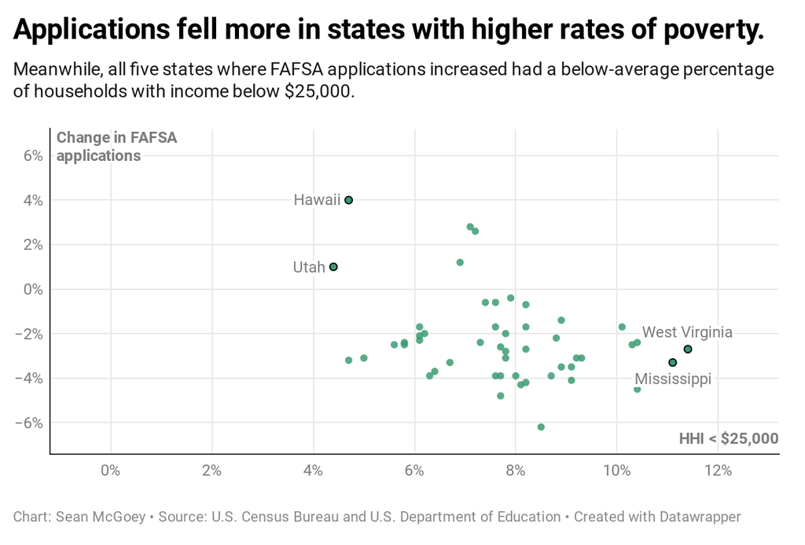

### Race

Next, I looked at how a **state’s racial demographics correlated with change in FAFSA applications**, especially considering the well-noted impact of COVID-19 on the Black population and reporting indicating [significant decreases in college enrollment among Black students in 2020](https://www.americanprogress.org/issues/education-postsecondary/reports/2020/09/28/490838/time-worry-college-enrollment-declines-among-black-students/).

```r
# build object with percentages of white/Black/Hispanic population and percent change in applications
state_race_applications <- state_data_combined %>%
  mutate(white_pct = white_pop / total_pop, black_pct = black_pop / total_pop, hispanic_pct = hispanic_pop / total_pop) %>%
  select(state, white_pct, black_pct, hispanic_pct, pct_change_apps)
```

```r
# run correlation tests for each racial population and percent change in applications
cor.test(state_race_applications$black_pct, state_race_applications$pct_change_apps)
```

```
##
##  Pearson's product-moment correlation
##
## data:  state_race_applications$black_pct and state_race_applications$pct_change_apps
## t = -1.5373, df = 49, p-value = 0.1307
## alternative hypothesis: true correlation is not equal to 0
## 95 percent confidence interval:
##  -0.46272842  0.06492389
## sample estimates:
##        cor
## -0.2144976
```

```r
cor.test(state_race_applications$hispanic_pct, state_race_applications$pct_change_apps)
```

```
##
##  Pearson's product-moment correlation
##
## data:  state_race_applications$hispanic_pct and state_race_applications$pct_change_apps
## t = 2.71, df = 49, p-value = 0.009247
## alternative hypothesis: true correlation is not equal to 0
## 95 percent confidence interval:
##  0.09488484 0.57900460
## sample estimates:
##       cor
## 0.3610281
```

```r
cor.test(state_race_applications$white_pct, state_race_applications$pct_change_apps)
```

```
##
##  Pearson's product-moment correlation
##
## data:  state_race_applications$white_pct and state_race_applications$pct_change_apps
## t = -2.5841, df = 49, p-value = 0.0128
## alternative hypothesis: true correlation is not equal to 0
## 95 percent confidence interval:
##  -0.56771314 -0.07818913
## sample estimates:
##        cor
## -0.3463106
```

The relationship between Black population and FAFSA application drops was not very strong and not statistically significant, but the relationship between Hispanic population and FAFSA application changes was fascinating: **States with higher percentages of Hispanic population were actually *less likely* to see their applications fall**.

And **the whiter a state was, the *more likely* applications were to fall**, which makes some intuitive sense considering that the list of states with the 10 largest drops in application volume includes Maine and Vermont, two far Northeastern states with 93% white populations, and Alabama and Arkansas, which are among the whitest states in the Deep South.

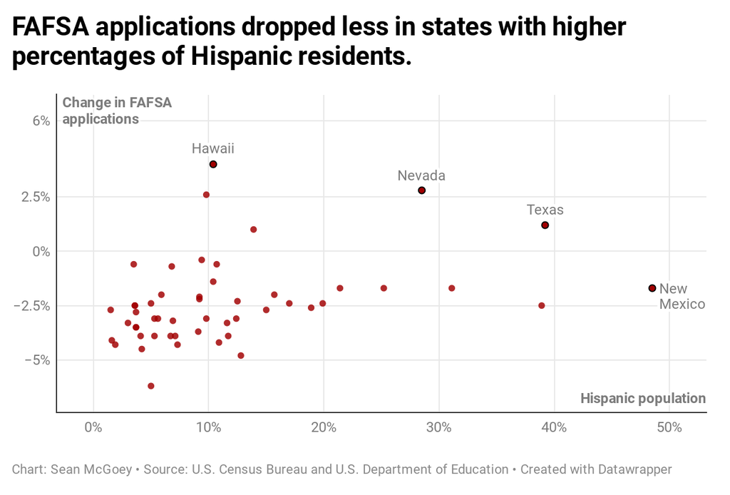

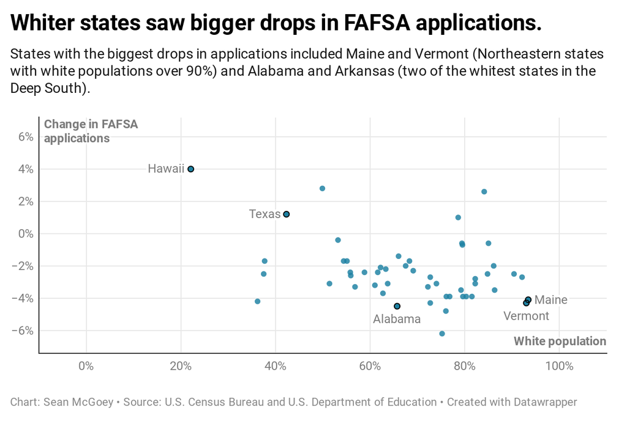

### Home ownership vs. renting

And finally, I wanted to determine whether there was a meaningful relationship between **home renting vs. ownership and FAFSA applications**.

```r
# build object with percentages of owners/renters and percent change in applications
state_home_applications <- state_data_combined %>%
  mutate(renter_pct = renter_pop / total_pop, owner_pct = owner_pop / total_pop) %>%
  select(state, renter_pct, owner_pct, pct_change_apps)
```

```r
# run correlation tests for own/rent and percent change in applications
cor.test(state_home_applications$owner_pct, state_home_applications$pct_change_apps)
```

```
##
##  Pearson's product-moment correlation
##
## data:  state_home_applications$owner_pct and state_home_applications$pct_change_apps
## t = -1.2671, df = 49, p-value = 0.2111
## alternative hypothesis: true correlation is not equal to 0
## 95 percent confidence interval:
##  -0.4324791  0.1024895
## sample estimates:
##        cor
## -0.1781252
```

```r
cor.test(state_home_applications$renter_pct, state_home_applications$pct_change_apps)
```

```
##
##  Pearson's product-moment correlation
##
## data:  state_home_applications$renter_pct and state_home_applications$pct_change_apps
## t = 1.5937, df = 49, p-value = 0.1174
## alternative hypothesis: true correlation is not equal to 0
## 95 percent confidence interval:
##  -0.05708955  0.46888579
## sample estimates:
##       cor
## 0.2219866
```

Neither relationship there is either strong or statistically significant.

# Conclusions

## Summary of findings

My analysis found that there was indeed a statistically significant drop in FAFSA applications at a state level from the 2019–2020 application cycle to the 2020–2021 cycle, though not at a county or ZIP code level for the state of Maryland.

Household income below $25,000 a year was positively correlated with larger drops in FAFSA applications, suggesting that students from already economically strained may be more likely to delay or forgo college enrollment during the pandemic. And in an interesting discovery, states with larger Hispanic populations avoided the largest drops in applications, consistent with data from the National Student Clearinghouse showing that [Hispanic students have seen some of the smallest declines in enrollment in 2020](https://www.studentclearinghouse.org/blog/fall-2020-undergraduate-enrollment-down-4-compared-to-same-time-last-year/).

## Limitations

One of the most obvious limitations of this analysis is that FAFSA applications are an imperfect proxy for interest in college enrollment. There are any number of reasons why a student might not fill out a FAFSA form at all — or simply after the window of time that I was able to examine.

## Future work

The primary logical extensions of this work would include replicating the analysis with actual enrollment numbers instead of FAFSA applications and incorporating other variables into the correlation analysis: public vs. private high schools, public vs. private colleges, etc.

# REFERENCES

[1] Paul Fain, 2019. **[College Enrollment Declines Continue](https://www.insidehighered.com/quicktakes/2019/05/30/college-enrollment-declines-continue)**. *Inside Higher Ed* (May 30, 2019)

[2] Todd Sedmak, 2020. **[Fall 2020 Undergraduate Enrollment Down 4% Compared to Same Time Last Year](https://www.studentclearinghouse.org/blog/fall-2020-undergraduate-enrollment-down-4-compared-to-same-time-last-year/)**. National Student Clearinghouse Media Center (Oct. 15, 2020)

[3] Lin, Yuxin., & Liu, Vivian (2019). **[Timing Matters: How Delaying College Enrollment Affects Earnings Trajectories](https://files.eric.ed.gov/fulltext/ED595238.pdf)**. *CCRC Working Paper No. 105 – Community College Research Center* (Feb 2019)

[4] Hemelt, S.W., & Marcotte, D.E. (2016). **[The Changing Landscape of Tuition and Enrollment in American Public Higher Education](http://doi.org/10.1353/rus.2016.0002)**. *RSF: The Russell Sage Foundation Journal of the Social Sciences 2(1)*, 42-68

[5] Meyer, Timothy J. (2017), **[“A Quantitative Study of Enrollment Change during the Great Recession at Non-selective Small Private Colleges and Universities”](https://ir.stthomas.edu/caps_ed_lead_docdiss/94)**. In *Education Doctoral Dissertations in Leadership*. 94.

[6] Abel, Jaison R. and Deitz, Richard (2014). **[Do the Benefits of College Still Outweigh the Costs?](https://ssrn.com/abstract=2477864)**. In *Current Issues in Economics and Finance*, Vol. 20, No. 3, 2014.